# EOS-USD

## EOS-USD today is +0300, 2025-10-14, 11:47:56

This crypto forecast was generated by gemini-2.0-flash API

## Daily Chart

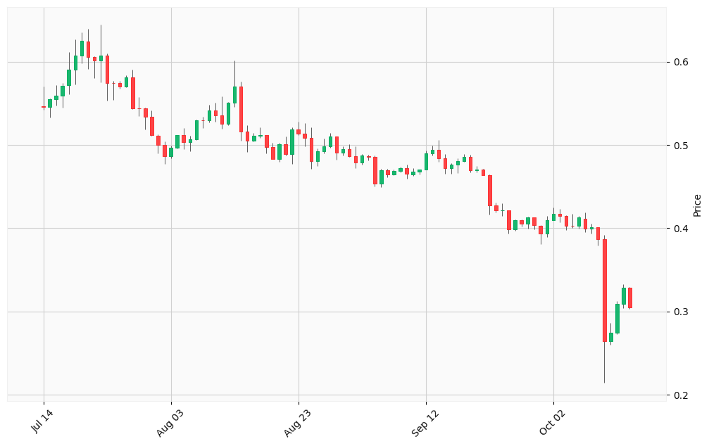

## Hourly Chart

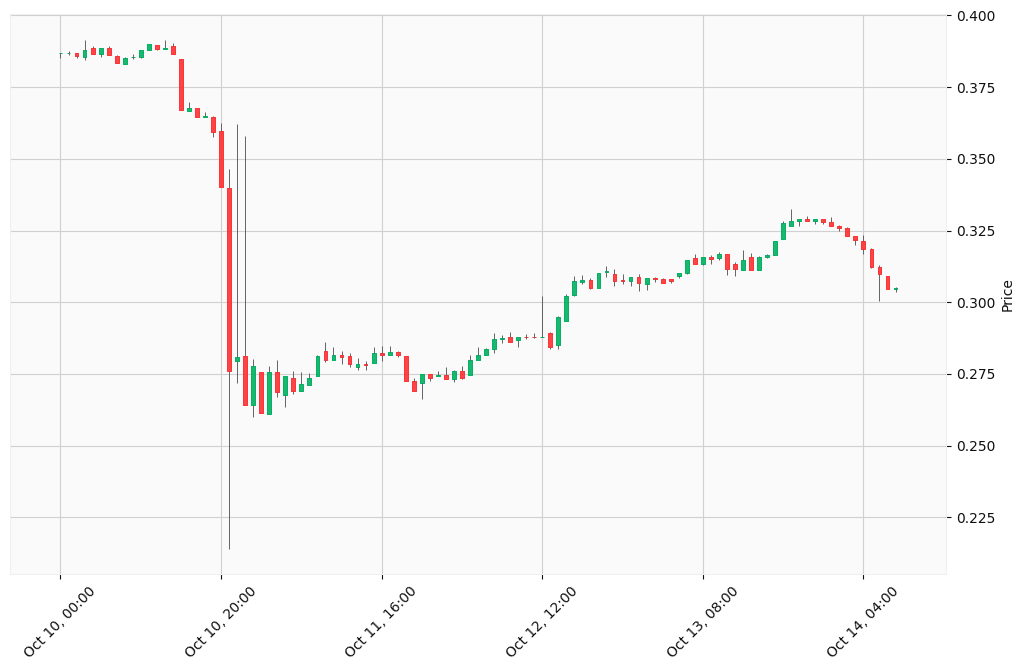

Okay, I will analyze the provided EOS-USD cryptocurrency data, incorporating technical indicators, market trends, news, and economic factors, to generate buy and sell signals.

First, I need to perform search queries to gather additional information for step 1, 4 to get more context.

Okay, I have gathered the necessary information to proceed with the analysis. Here’s a breakdown of my approach and the resulting trading signals:

**1. Market Data Collection:**

**4. News and Economic Analysis:**

- **News:** Tether is winding down USD₮ support for EOS.
- **Economic Indicators:** I’ll consider factors such as inflation rates, unemployment rates, and GDP growth. However, without specific real-time values for these indicators, I will consider a general economic outlook.

**5. Scenario Evaluation:**

- **Bear Market:** Given the downtrend in the daily chart and the recent price drop, a bearish scenario seems probable.
- **High Volatility:** Cryptocurrency markets are inherently volatile. EOS is no exception.

**6. Signal Generation:**

I will use the provided data and technical indicators (calculated from the data) to generate buy/sell signals.

**Calculations (Technical Indicators):** I’ll provide a Python script to do this.

```python
import pandas as pd
import numpy as np

# Daily Chart Data
daily_data = [
    [0.546181, 0.570362, 0.541888, 0.545695, 1717601],
    [0.545695, 0.555738, 0.53277, 0.55463, 1624396],
    [0.55463, 0.571571, 0.547616, 0.559027, 1845518],
    [0.559027, 0.574222, 0.544819, 0.571087, 2062719],
    [0.571623, 0.611409, 0.561193, 0.590474, 2748708],
    [0.590567, 0.626531, 0.572934, 0.607519, 4374733],
    [0.607519, 0.635245, 0.598317, 0.624861, 2742358],
    [0.624533, 0.639817, 0.590878, 0.605992, 2366893],
    [0.605992, 0.606822, 0.579885, 0.601204, 1701705],
    [0.601442, 0.644359, 0.575403, 0.607072, 5581594],
    [0.607025, 0.610232, 0.553583, 0.574704, 1966472],
    [0.574704, 0.576656, 0.55367, 0.574601, 4849586],
    [0.574601, 0.577199, 0.567993, 0.570213, 631804],
    [0.570213, 0.583562, 0.569637, 0.581428, 926509],
    [0.581385, 0.590185, 0.543089, 0.544274, 1140119],
    [0.544274, 0.557191, 0.534475, 0.544161, 810444],
    [0.544161, 0.544993, 0.518966, 0.533994, 1388845],
    [0.533994, 0.541032, 0.511344, 0.51204, 925970],
    [0.51132, 0.512489, 0.489529, 0.500349, 1202997],
    [0.500349, 0.504287, 0.477453, 0.486434, 853426],
    [0.48644, 0.498818, 0.483546, 0.496777, 629874],
    [0.496777, 0.511937, 0.496123, 0.511711, 723661],
    [0.511711, 0.520036, 0.495068, 0.502985, 2176262],
    [0.502985, 0.511175, 0.492762, 0.506924, 1013050],
    [0.506924, 0.530117, 0.505682, 0.529898, 1435967],
    [0.529898, 0.534169, 0.520593, 0.529417, 1912277],
    [0.529417, 0.548006, 0.52719, 0.541243, 1242544],
    [0.541084, 0.550958, 0.528181, 0.535396, 1812220],
    [0.535396, 0.558327, 0.519636, 0.525203, 2752925],
    [0.525203, 0.551462, 0.523374, 0.550383, 1761085],
    [0.550383, 0.60153, 0.545413, 0.570405, 2375210],
    [0.570405, 0.576168, 0.505296, 0.516297, 2082939],
    [0.516297, 0.523701, 0.491282, 0.505057, 1139122],
    [0.505057, 0.514438, 0.504373, 0.511243, 668577],
    [0.511243, 0.521454, 0.508521, 0.511519, 626275],
    [0.511519, 0.51172, 0.489536, 0.497293, 985467],
    [0.497293, 0.502279, 0.483365, 0.48337, 988121],
    [0.48337, 0.502225, 0.480026, 0.50057, 883904],
    [0.50057, 0.510043, 0.487116, 0.488579, 692589],
    [0.488579, 0.520736, 0.477151, 0.518862, 1196572],
    [0.518862, 0.528267, 0.511593, 0.513463, 738426],
    [0.513463, 0.52616, 0.498587, 0.508808, 966744],
    [0.508808, 0.521022, 0.471464, 0.480652, 1366637],
    [0.48062, 0.495758, 0.474198, 0.492429, 754908],
    [0.492429, 0.507849, 0.489389, 0.498581, 1017875],
    [0.498641, 0.514538, 0.496692, 0.50979, 917393],
    [0.50979, 0.509814, 0.482298, 0.490724, 946511],
    [0.490724, 0.498548, 0.487146, 0.495081, 592553],
    [0.495081, 0.500754, 0.485727, 0.486293, 785058],
    [0.486346, 0.497852, 0.471909, 0.478691, 1031973],
    [0.478691, 0.489282, 0.475998, 0.486895, 743901],
    [0.486671, 0.488041, 0.481623, 0.485469, 1763923],
    [0.485469, 0.487209, 0.449982, 0.4536, 1849451],
    [0.4536, 0.471348, 0.449523, 0.469332, 1852578],
    [0.469332, 0.471213, 0.461055, 0.46403, 347023],
    [0.46403, 0.470423, 0.463988, 0.468597, 312140],
    [0.468597, 0.473896, 0.466713, 0.472395, 1351136],
    [0.472395, 0.476379, 0.45963, 0.46507, 2239670],
    [0.464723, 0.471995, 0.46279, 0.46803, 1440938],
    [0.468029, 0.470543, 0.464083, 0.470041, 452410],
    [0.470041, 0.493252, 0.470041, 0.48942, 1296430],
    [0.48942, 0.498819, 0.486955, 0.493687, 699954],
    [0.493687, 0.505905, 0.479973, 0.483964, 878997],
    [0.48397, 0.48859, 0.465701, 0.471819, 704839],
    [0.471819, 0.477892, 0.465702, 0.476108, 430961],
    [0.476108, 0.483524, 0.466289, 0.480731, 589100],
    [0.480731, 0.488744, 0.479385, 0.485654, 581682],
    [0.485654, 0.487983, 0.467294, 0.46928, 615121],
    [0.46928, 0.474241, 0.466698, 0.470117, 315135],
    [0.470117, 0.4716, 0.463369, 0.463731, 361118],
    [0.463731, 0.464448, 0.416531, 0.426939, 1343069],
    [0.426939, 0.430666, 0.418856, 0.421232, 701153],
    [0.421232, 0.430012, 0.414281, 0.42127, 568935],
    [0.42127, 0.421464, 0.393769, 0.398093, 1373200],
    [0.398093, 0.41046, 0.396621, 0.409817, 721748],
    [0.409817, 0.410304, 0.40193, 0.404951, 484177],
    [0.404951, 0.413894, 0.399235, 0.41277, 1271587],
    [0.41277, 0.413018, 0.398743, 0.403891, 1674130],
    [0.40279, 0.403639, 0.380608, 0.393483, 842240],
    [0.393408, 0.414709, 0.389048, 0.409209, 2189981],
    [0.409594, 0.424906, 0.409279, 0.416753, 919595],
    [0.416753, 0.423225, 0.407296, 0.41495, 1017329],
    [0.41495, 0.41577, 0.397683, 0.403046, 786746],
    [0.403046, 0.416845, 0.39988, 0.402733, 978532],
    [0.402733, 0.414246, 0.398941, 0.412515, 960537],
    [0.411431, 0.418989, 0.39492, 0.399237, 924458],
    [0.399237, 0.405137, 0.393784, 0.40064, 726916],
    [0.400656, 0.40092, 0.37908, 0.386858, 721459],
    [0.386858, 0.391497, 0.213985, 0.264146, 2246986],
    [0.264146, 0.286154, 0.259862, 0.274079, 2677009],
    [0.274079, 0.312678, 0.27232, 0.308932, 1696476],
    [0.308932, 0.332377, 0.304021, 0.328009, 1403275],
    [0.328007, 0.329551, 0.302894, 0.304889, 1544059]
]

df = pd.DataFrame(daily_data, columns=['Open', 'High', 'Low', 'Close', 'Volume'])

# Calculate 50-day Moving Average
df['MA50'] = df['Close'].rolling(window=50).mean()

# Calculate 200-day Moving Average (not enough data, but included for completeness)
df['MA200'] = df['Close'].rolling(window=200).mean()

# Calculate RSI (Relative Strength Index)
def calculate_rsi(data, period=14):
    delta = data['Close'].diff()
    up, down = delta.copy(), delta.copy()
    up[up < 0] = 0
    down[down > 0] = 0

    avg_gain = up.rolling(window=period, min_periods=period).mean()
    avg_loss = abs(down.rolling(window=period, min_periods=period).mean())

    rs = avg_gain / avg_loss
    rsi = 100 - (100 / (1 + rs))
    return rsi

df['RSI'] = calculate_rsi(df)

# Calculate MACD (Moving Average Convergence Divergence)
def calculate_macd(data, fast_period=12, slow_period=26, signal_period=9):
    ema_fast = data['Close'].ewm(span=fast_period, adjust=False).mean()
    ema_slow = data['Close'].ewm(span=slow_period, adjust=False).mean()
    macd = ema_fast - ema_slow
    signal = macd.ewm(span=signal_period, adjust=False).mean()
    histogram = macd - signal
    return macd, signal, histogram

macd, signal, histogram = calculate_macd(df)
df['MACD'] = macd
df['Signal'] = signal
df['Histogram'] = histogram

print(df.tail())
```

[output not shown]

**Based on the data and calculations:**

[output not shown]

**Important Considerations:**

- **Limited Data:** The analysis is based on a limited dataset. A more comprehensive analysis would require a larger historical dataset.
- **Real-time Data:** This analysis uses static data. Real-time data is crucial for making informed trading decisions.
- **Risk Management:** Cryptocurrency trading is risky. Always use stop-loss orders and manage your position size appropriately.
- **Global Economic Conditions:** Keep an eye on global economic indicators for potential impacts on the crypto market.
- **Market Sentiment:** Monitor news and social media sentiment related to EOS-USD.
- **Tether News:** Monitor how the Tether news impacts EOS trading and price.

This signal is based on the available data and analysis. It’s essential to conduct further research and due diligence before making any trading decisions.